# Healthcare PGP

### Problem Statement

NIDDK (National Institute of Diabetes and Digestive and Kidney Diseases) research creates knowledge about and treatments for the most chronic, costly, and consequential diseases. The dataset used in this project is originally from NIDDK. The objective is to predict whether or not a patient has diabetes, based on certain diagnostic measurements included in the dataset. Build a model to accurately predict whether the patients in the dataset have diabetes or not. Dataset Description The datasets consists of several medical predictor variables and one target variable (Outcome). Predictor variables includes the number of pregnancies the patient has had, their BMI, insulin level, age, and more.

| Variables | Description |
| --- | --- |
| Pregnancies | Number of times pregnant |
| Glucose | Plasma glucose concentration in an oral glucose tolerance test |
| BloodPressure | Diastolic blood pressure (mm Hg) |
| SkinThickness | Triceps skinfold thickness (mm) |
| Insulin | Two hour serum insulin |
| BMI | Body Mass Index |
| DiabetesPedigreeFunction | Diabetes pedigree function |
| Age | Age in years |
| Outcome | Class variable (either 0 or 1). 268 of 768 values are 1, and the others are 0 |

## Project Task: Week 1

### Data Exploration:

1. Perform descriptive analysis. Understand the variables and their corresponding values. On the columns below, a value of zero does not make sense and thus indicates missing value: • Glucose • BloodPressure • SkinThickness • Insulin • BMI 2. Visually explore these variables using histograms. Treat the missing values accordingly. 3. There are integer and float data type variables in this dataset. Create a count (frequency) plot describing the data types and the count of variables.

#### Code is written below:

```python
import numpy as np
import pandas as pd
import matplotlib.pyplot as plt
import seaborn as sns

df = pd.read_csv("health care diabetes.csv")
df.head()
```

|  | Pregnancies | Glucose | BloodPressure | SkinThickness | Insulin | BMI | DiabetesPedigreeFunction | Age | Outcome |
| --- | --- | --- | --- | --- | --- | --- | --- | --- | --- |
| 0 | 6 | 148 | 72 | 35 | 0 | 33.6 | 0.627 | 50 | 1 |
| 1 | 1 | 85 | 66 | 29 | 0 | 26.6 | 0.351 | 31 | 0 |
| 2 | 8 | 183 | 64 | 0 | 0 | 23.3 | 0.672 | 32 | 1 |
| 3 | 1 | 89 | 66 | 23 | 94 | 28.1 | 0.167 | 21 | 0 |
| 4 | 0 | 137 | 40 | 35 | 168 | 43.1 | 2.288 | 33 | 1 |

```python
#Checking for null or Nan values:
df.isnull().sum()
```

```
Pregnancies                 0
Glucose                     0
BloodPressure               0
SkinThickness               0
Insulin                     0
BMI                         0
DiabetesPedigreeFunction    0
Age                         0
Outcome                     0
dtype: int64
```

### Descriptive Analysis :

Descriptive Analysis is the first and important step to be performed in Machine Learning. It helps to understand the data and helps us in detecting outliers and even helps in getting the relation between the variables, thus it helps for further analysis.

Let us check if any value '0' is present for *Glucose, BloodPressure, SkinThickness, Insulin, BMI* variables and replace them with their median values(if any).

#### Code is written below:

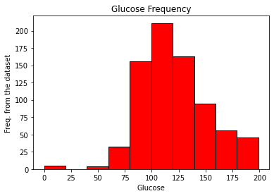

```python
df['Glucose'].plot.hist(color = 'red',edgecolor = 'black')
plt.xlabel('Glucose')
plt.ylabel('Freq. from the dataset')
plt.title('Glucose Frequency')
plt.show()
```

```python
#replacing 0 values with its median values
print("The median for Glucose data is ",df['Glucose'].median())
df['Glucose'] = df['Glucose'].replace(0,df['Glucose'].median())
```

```
The median for Glucose data is  117.0
```

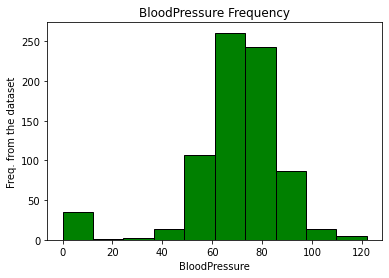

```python
df['BloodPressure'].plot.hist(color = 'green',edgecolor = 'black')
plt.xlabel('BloodPressure')
plt.ylabel('Freq. from the dataset')
plt.title('BloodPressure Frequency')
plt.show()
```

```python
#replacing 0 values with its median values
print("The median for BloodPressure data is ",df['BloodPressure'].median())
df['BloodPressure'] = df['BloodPressure'].replace(0,df['BloodPressure'].median())
```

```
The median for BloodPressure data is  72.0
```

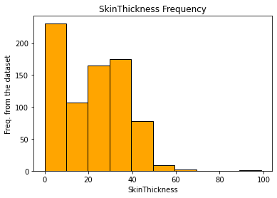

```python
df['SkinThickness'].plot.hist(color = 'orange',edgecolor = 'black')
plt.xlabel('SkinThickness')
plt.ylabel('Freq. from the dataset')
plt.title('SkinThickness Frequency')
plt.show()
```

```python
#replacing 0 values with its median values
print("The median for SkinThickness data is ",df['SkinThickness'].median())
df['SkinThickness'] = df['SkinThickness'].replace(0,df['SkinThickness'].median())
```

```
The median for SkinThickness data is  23.0
```

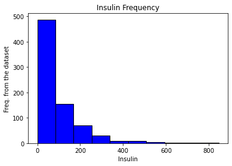

```python
df['Insulin'].plot.hist(color = 'blue',edgecolor = 'black')
plt.xlabel('Insulin')
plt.ylabel('Freq. from the dataset')
plt.title('Insulin Frequency')
plt.show()
```

```python
#replacing 0 values with its median values
print("The median for Insulin data is ",df['Insulin'].median())
df['Insulin'] = df['Insulin'].replace(0,df['Insulin'].median())
```

```
The median for Insulin data is  30.5
```

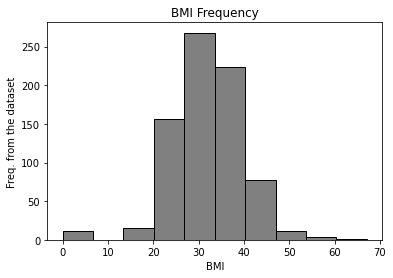

```python
df['BMI'].plot.hist(color = 'grey',edgecolor = 'black')
plt.xlabel('BMI')
plt.ylabel('Freq. from the dataset')
plt.title('BMI Frequency')
plt.show()
```

```python
#replacing 0 values with its median values
print("The median for BMI data is ",df['BMI'].median())
df['BMI'] = df['BMI'].replace(0,df['BMI'].median())
```

```
The median for BMI data is  32.0
```

After replacing the variables with their respective median values, we get the new Data frame as shown below.

```python
df.head(n=10)
```

|  | Pregnancies | Glucose | BloodPressure | SkinThickness | Insulin | BMI | DiabetesPedigreeFunction | Age | Outcome |
| --- | --- | --- | --- | --- | --- | --- | --- | --- | --- |
| 0 | 6 | 148 | 72 | 35 | 30.5 | 33.6 | 0.627 | 50 | 1 |
| 1 | 1 | 85 | 66 | 29 | 30.5 | 26.6 | 0.351 | 31 | 0 |
| 2 | 8 | 183 | 64 | 23 | 30.5 | 23.3 | 0.672 | 32 | 1 |
| 3 | 1 | 89 | 66 | 23 | 94.0 | 28.1 | 0.167 | 21 | 0 |
| 4 | 0 | 137 | 40 | 35 | 168.0 | 43.1 | 2.288 | 33 | 1 |
| 5 | 5 | 116 | 74 | 23 | 30.5 | 25.6 | 0.201 | 30 | 0 |
| 6 | 3 | 78 | 50 | 32 | 88.0 | 31.0 | 0.248 | 26 | 1 |
| 7 | 10 | 115 | 72 | 23 | 30.5 | 35.3 | 0.134 | 29 | 0 |
| 8 | 2 | 197 | 70 | 45 | 543.0 | 30.5 | 0.158 | 53 | 1 |
| 9 | 8 | 125 | 96 | 23 | 30.5 | 32.0 | 0.232 | 54 | 1 |

### Create a count (frequency) plot describing the data types and the count of variables

```python
df.dtypes
```

```
Pregnancies                   int64
Glucose                       int64
BloodPressure                 int64
SkinThickness                 int64
Insulin                     float64
BMI                         float64
DiabetesPedigreeFunction    float64
Age                           int64
Outcome                       int64
dtype: object
```

```python
df.dtypes.value_counts()
```

```
int64      6
float64    3
dtype: int64
```

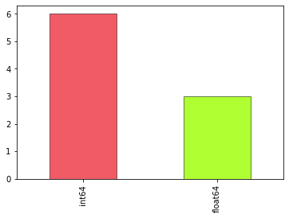

```python
df.dtypes.value_counts().plot(kind="bar", color = ['#f05b66','#afff33'], edgecolor = 'black', linewidth = 0.5)
plt.title('')
plt.show()
```

## Project Task: Week 2

### Data Exploration:

1. Check the balance of the data by plotting the count of outcomes by their value. Describe your findings and plan future course of action. 2. Create scatter charts between the pair of variables to understand the relationships. Describe your findings. 3. Perform correlation analysis. Visually explore it using a heat map.

#### Code is written below:

```python
df['Outcome'].value_counts()
```

```
0    500
1    268
Name: Outcome, dtype: int64
```

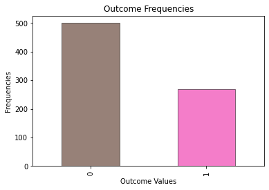

```python
# plotting the outcome values
df['Outcome'].value_counts().plot(kind="bar", color = ['#978178','#f47dc9'], edgecolor = 'black', linewidth=0.5)
plt.xlabel('Outcome Values')
plt.ylabel('Frequencies')
plt.title('Outcome Frequencies')
plt.show()
```

### Performing correlation analysis and Visually exploring it using a heat map.

A heatmap is a graphical representation of data that uses a system of color-coding to represent different values. The correlation between the elements can be figured out using Heatmap.

#### Code is written below:

```python
#creating correlation matrix by dropping the Outcome row
df_temp = ['Outcome']
df_corr = df.corr()
df_corr.drop(df_temp, inplace = True)
df_corr.drop(df_temp,axis=1,inplace = True)
```

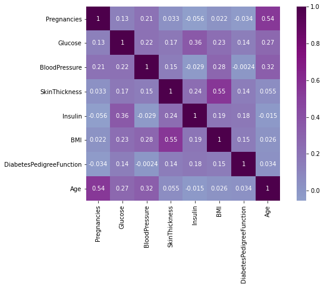

```python
#creating heatmap
fig=plt.gcf()
fig.set_size_inches(10,6)
ax = sns.heatmap(df_corr, center=0,square=True,annot=True , cmap="BuPu")
```

From the above heatmap, we find the correlation between variables.

#### Top 5 correlations from the given Data set

| Variables | Correlation value |
| --- | --- |
| Skin Thickness (vs) BMI | 0.55 |
| Pregnancies (vs) Age | 0.54 |
| Glucose (vs) Insulin | 0.36 |
| Bloodpressure (vs) Age | 0.32 |
| Bloodpressure (vs) BMI | 0.28 |

### Creating the Scatter Plot for the above mentioned Variables for better understanding of their correlation

#### Code is written below:

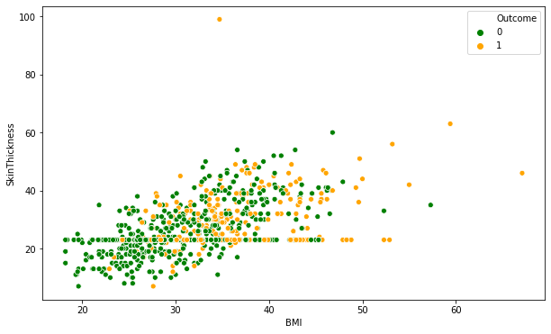

```python
#Skin Thickness (vs) BMI
fig=plt.gcf()
fig.set_size_inches(10,6)
sns.scatterplot(x='BMI',y='SkinThickness',data = df,hue='Outcome',palette=['green','orange'])
plt.show()
```

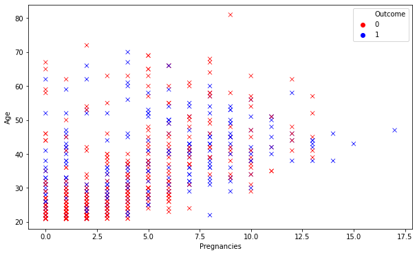

```python
#Pregnancies (vs) Age
fig=plt.gcf()
fig.set_size_inches(10,6)
sns.scatterplot(x='Pregnancies',y='Age',data = df,hue='Outcome',palette=['red','blue'],marker='x')
plt.show()
```

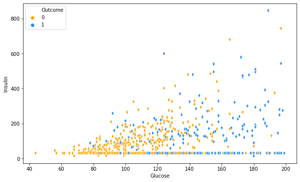

```python
# Glucose (vs) Insulin
fig=plt.gcf()
fig.set_size_inches(10,6)
sns.scatterplot(x='Glucose',y='Insulin',data = df,hue='Outcome',palette=['orange','dodgerblue'],marker='d')
plt.show()
```

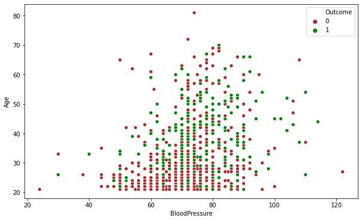

```python
#Bloodpressure (vs) Age
fig=plt.gcf()
fig.set_size_inches(10,6)
sns.scatterplot(x='BloodPressure',y='Age',data = df,hue='Outcome',palette=['brown','green'])
plt.show()
```

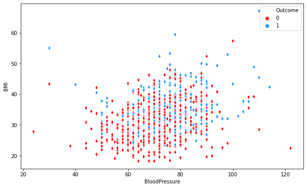

```python
# Bloodpressure (vs) BMI
fig=plt.gcf()
fig.set_size_inches(10,6)
sns.scatterplot(x='BloodPressure',y='BMI',data = df,hue='Outcome',palette=['red','dodgerblue'],marker='d')
plt.show()
```